```r
glove = read_delim(file = "../glove.6B.100d.txt",
                   progress =FALSE,
                   col_names = FALSE, delim = " ", quote = "")
```

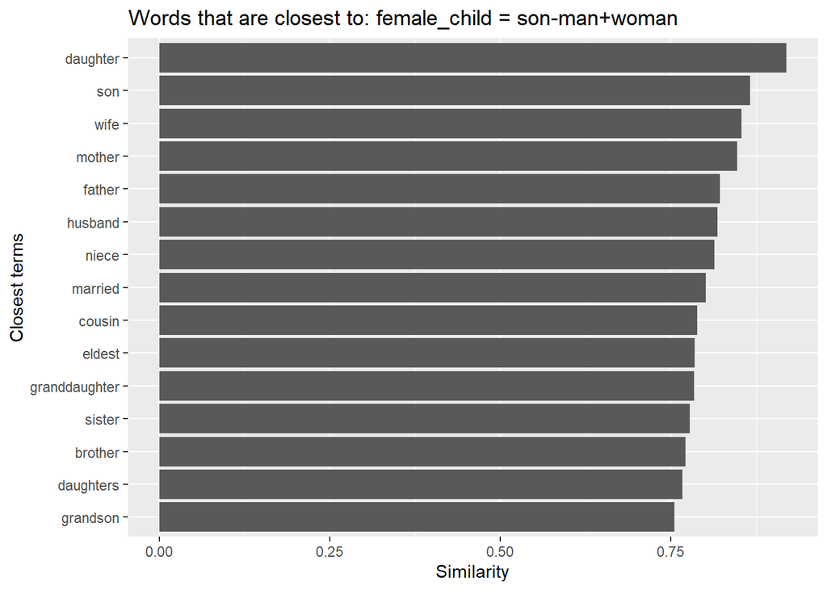

```r
names(glove)[1] = "token"

## Extract vectors for king, man, and queen
man = glove %>% filter(token=="man") %>% select(-token)
son = glove%>%filter(token=="son") %>% select(-token)
woman = glove%>%filter(token=="woman") %>% select(-token)

## Calculate woman analog of son
# daughter-woman = son-man
female_child = son-man+woman

## Convert the glove and female_child data frames into vectors
x = glove %>% select(-token) %>% as.matrix() # The
y = as.matrix(female_child) # Vector

library(text2vec)
## Calculate the cosine distance between "female_child" and all other word embedding
cos_sim = sim2(x, y, method = "cosine", norm = "l2")

# Identify and plot similar words
similar_words = cbind(glove$token, cos_sim) %>% # Matches word embedding to words
  as.tibble() %>%
  mutate(term = V1, similarity = as.numeric(V2)) %>%
  arrange(desc(similarity)) %>% dplyr::slice(1:15)

ggplot(similar_words, aes(reorder(term, similarity), similarity)) +
  geom_col() +
  coord_flip() +
  labs(title = "Words that are closest to: female_child = son-man+woman",
       x = "Closest terms", y = "Similarity")
```

[figure not shown]

```r
## Similar to sentiment lexicon, word embeddings can be added to describe the terms in documents
glovec.text.df = text.df %>%
  inner_join(glove, by=c("term" = "token"))

## Document embeddings can be created by averaging the term embedding
s.glovec.text.df = glovec.text.df %>%
  gather(key = glovec_id, value = glovalue, contains("X")) %>%
  group_by(document, glovec_id) %>%
  summarise(m.glovalue = mean(glovalue)) %>%
  spread(key = glovec_id, value = m.glovalue) %>%
  ungroup()

## Calculate document distance based on cosine similarity of generic embedding

doc.similiarity.mat = cosine(t(s.glovec.text.df %>% select(contains("X")) %>% as.matrix()))
row.names(doc.similiarity.mat) = as.vector(s.glovec.text.df$document)

doc.dissimilarity.dist = as.dist(1-doc.similiarity.mat)


## Hierarchical clustering of documents
# Setting method = ward.d2 corresponds to agnes clustering
doc.cluster = hclust(doc.dissimilarity.dist, method = "ward.D2", members = NULL)
plot(doc.cluster)
```

#The GLOVE UMAP represents the reading in a beter way as compared to LSA UMAP as the GLOVE UMAP has well defined clusters with clearly defined boundaries and the documents have more cor-relation in the GLOVE UMAP as compared to the LSA UMAP

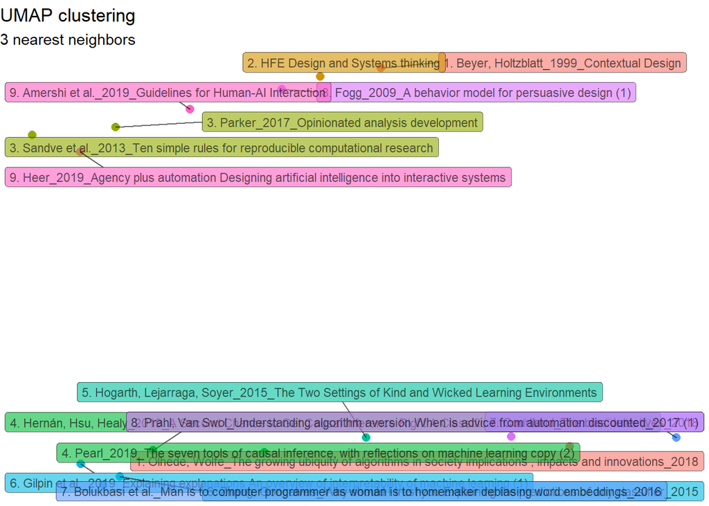

```r
doc.umap = s.glovec.text.df %>% select(starts_with("X")) %>%
   umap(n_neighbors = 3, n_components = 2) %>%
   as.tibble()
 names(doc.umap) = c("umap_1", "umap_2")
 doc.umap = cbind(docs.df, doc.umap)


doc.umap.plot =
  ggplot(doc.umap, aes(umap_1, umap_2)) +
  geom_point(aes(colour = number), size = 2.5) +
  geom_label_repel(aes(label = document, fill = number), alpha = .6, size = 3) +
  labs(title = "UMAP clustering", subtitle = "3 nearest neighbors") +
  theme_void()+
  theme(legend.position = "none")
doc.umap.plot
```

[figure not shown]

```r
## Match terms to glove embedding
terms.df = tfidf.text.df %>% group_by(term) %>%
  summarise(m.tf_idf = max(tf_idf)) %>%
  inner_join(glove, by=c("term" = "token"))

## Calculate umap dimensions
term.umap = terms.df %>% select(starts_with("X")) %>%
  umap(n_neighbors = 10, n_components = 2) %>%
  as.tibble()
names(term.umap) = c("umap_1", "umap_2")

term.umap =  terms.df %>%
  cbind(term.umap)


## Plot UMAP of terms
term.umap.plot =
  ggplot(term.umap, aes(umap_1, umap_2)) +
  geom_point(aes(size=m.tf_idf),shape = 21) +
  geom_label_repel(data = term.umap %>% top_n(100, m.tf_idf),
                   aes(label = term), alpha = .6, size = 3) +
  labs(title = "UMAP clustering", subtitle = "20 nearest neighbors") +
  theme_void()+
  theme(legend.position = "none")
term.umap.plot
```

The combined embedding does a better job as it is able to capture better the nuances of word and sensesas compared to the previous ones.

[figure not shown]

```r
combined.embedding = cbind(s.glovec.text.df, lsa_model$dk)

glovector = s.glovec.text.df %>% select(contains("X")) %>% as.matrix


combined.embedding.kcca = kcca(lsa_model$dk, glovector,
     kernel="rbfdot", kpar=list(sigma=0.1),
     gamma = 0.1, ncomps = 30)

combined.embedding.kcca.mat = cbind(combined.embedding.kcca@xcoef, combined.embedding.kcca@xcoef)


doc.similiarity.mat = cosine(t(combined.embedding.kcca.mat))
row.names(doc.similiarity.mat) = as.vector(s.glovec.text.df$document)

doc.dissimilarity.dist = as.dist(1-doc.similiarity.mat)


## Hierarchical clustering
# Setting method = ward.d2 corresponds to agnes clustering
doc.cluster = hclust(doc.dissimilarity.dist, method = "ward.D2", members = NULL)
plot(doc.cluster)
```